# Lab 3: MATH 4753

Hunter DeVoe

January 30, 2023

# Task 1

- Get the current working directory

```r
getwd()
```

```
## [1] "C:/Users/Hunter/Desktop/Math 4753 Labs/Lab3"
```

# Task 2

- Read in the SPRUCE.csv file and print the first six lines

```r
spruce = read.csv("SPRUCE.csv")
head(spruce)
```

```
##   BHDiameter Height
## 1       18.9   20.0
## 2       16.6   18.8
## 3       15.5   16.8
## 4       15.5   16.9
## 5       19.4   20.2
## 6       13.7   16.3
```

# Task 3

- Make a scatter plot of the SPRUCE data (y axis will be the Height).
  - Make sure it has a heading
  - Y axis is labelled
  - X axis is labelled
  - Points are filled blue, use pch=21 and bg=“Blue”
  - The points are 1.2Xs the default character size (use cex=1.2)
  - The y and x axes are adjusted to include 0 and 1.1 * max(y), and 0 and 1.1 * max(x) respectively

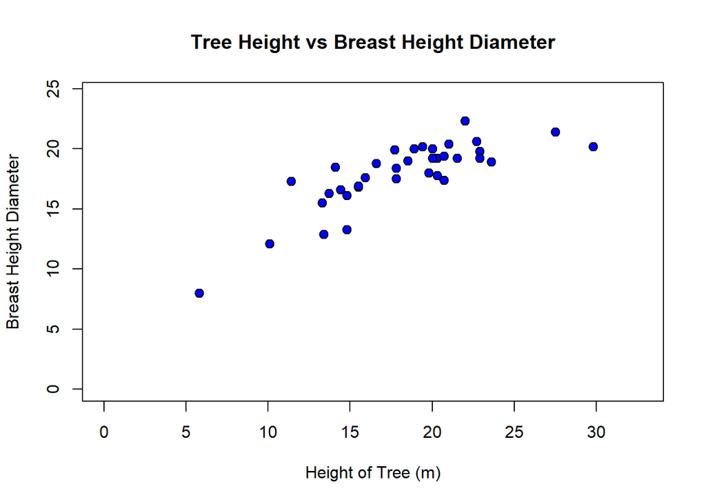

```r
plot(Height~BHDiameter, bg = "Blue", pch = 21, cex = 1.2, ylim = c(0, max(Height) * 1.1), xlim = c(0, max(BHDiameter) * 1.1), main = "Tree Height vs Breast Height Diameter", xlab = "Height of Tree (m)", ylab = "Breast Height Diameter", data = spruce)
```

- Does there appear to be a straight line relationship?

There does not appear to be a straight line relationship. If you analyze the scatter plot very closely, you can see the points increase and then begin to plateau when BHDiameter is between 15 and 25.

- Load the library s20x and make a lowess smoother scatter plot using trendscatter() (try a few values of f, f=0.5,0.6,0.7) record all three plots, use layout().

```r
layout = layout(matrix(1:3, nrow = 1, ncol = 3, byrow = TRUE))
tsone = trendscatter(Height~BHDiameter, f = 0.5, data = spruce)
tstwo = trendscatter(Height~BHDiameter, f = 0.6, data = spruce)
tsthree = trendscatter(Height~BHDiameter, f = 0.7, data = spruce)
```

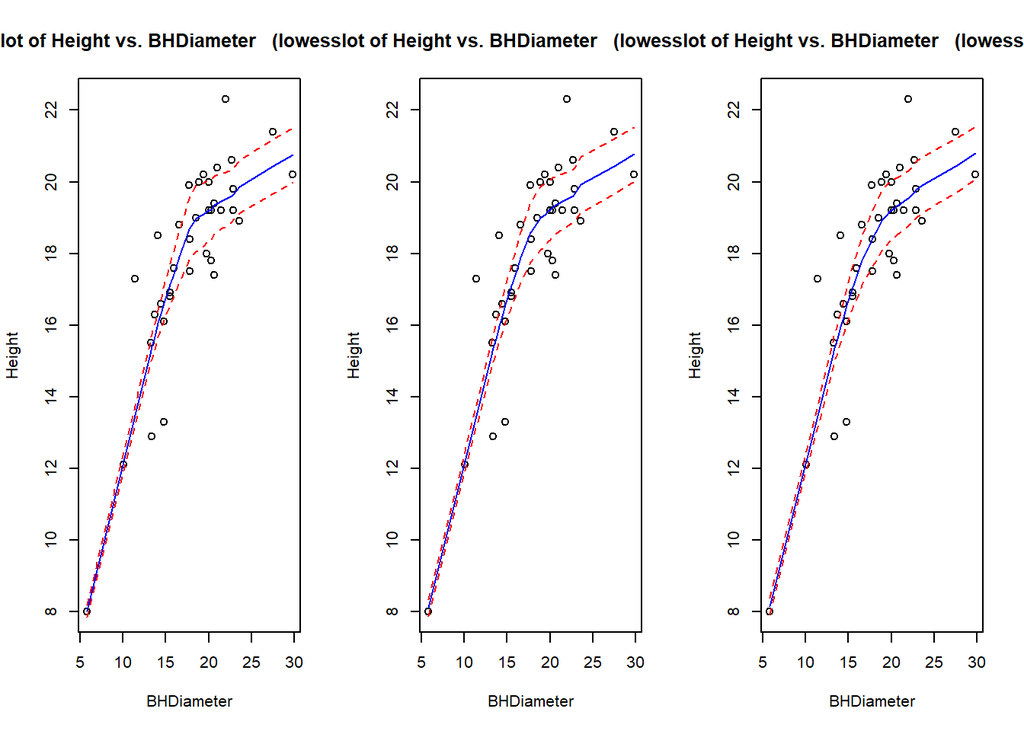

- We will assume (this may in fact be a bad assumption) a straight line relationship, use lm and make a linear model object, call it spruce.lm

```r
spruce.lm = with(spruce, lm(Height~BHDiameter))
```

- Make a new scatter plot and add the least squares regression line to the points -abline(spruce.lm) – record the plot.

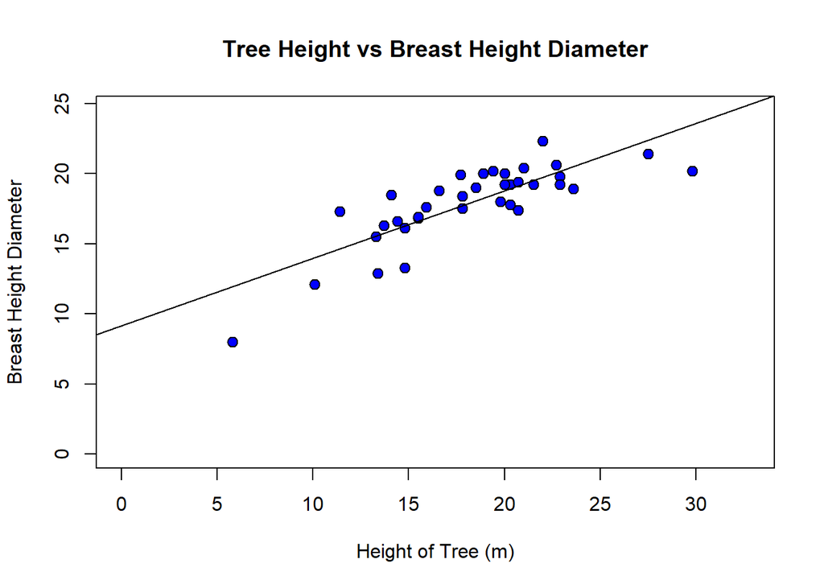

```r
layout = layout(1)

plot(Height~BHDiameter, bg = "Blue", pch = 21, cex = 1.2, ylim = c(0, max(Height) * 1.1), xlim = c(0, max(BHDiameter) * 1.1), main = "Tree Height vs Breast Height Diameter", xlab = "Height of Tree (m)", ylab = "Breast Height Diameter", data = spruce)

abline(spruce.lm)
```

- Comment on the graph, is a straight line appropriate? Consider the smoother curve also.

A straight line definitely works - the scatterplot does not have such a drastic curve that the line looks wrong. However, it is easy to tell that our straight line is not as accurate as possible and a curved line would be more suitable for our data. This point is backed up by the fact that we created three trendscatter plots, and all three of them had a clear curve in them near the top.

# Task 4

- Divide the graphical interface into 4 equal areas, use layout.show(4) and record the picture
  - In the first square, plot the scatter plot and fitted line.
  - In the second square plot the same with the residual line segments (deviations about the fitted line). (RSS=residual sum of squares)
  - In the third square plot the mean of Y versus X i.e. mean of Height vs BHDiameter, with the fitted line and deviations of the fitted line from the mean height added. (MSS=model sum of squares)
  - In the fourth square plot the mean of Height versus BHDiameter and show the total deviation line segments y ̂=y ̅. (TSS=total sum of squares)

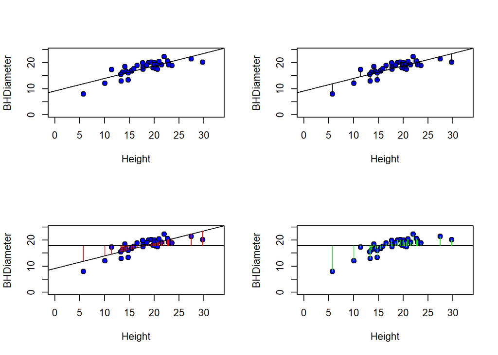

```r
layout(matrix(1:4,nr=2,nc=2,byrow=TRUE))

# Plot 1
plot(Height~BHDiameter, bg = "Blue", pch = 21, cex = 1.2, ylim = c(0, max(Height) * 1.1), xlim = c(0, max(BHDiameter) * 1.1), xlab = "Height", ylab = "BHDiameter", data = spruce)
abline(spruce.lm)

# Plot 2
plot(Height~BHDiameter, bg = "Blue", pch = 21, cex = 1.2, ylim = c(0, max(Height) * 1.1), xlim = c(0, max(BHDiameter) * 1.1), xlab = "Height", ylab = "BHDiameter", data = spruce)

#make yhat the estimates of E[HEAT | RATIO]
yhat=with(spruce,predict(spruce.lm,data.frame(BHDiameter)))
#OR you could use -- (yhat values the predicted values for all the RATIO values )
yhat=fitted(spruce.lm)

# Draw in segments making the residuals (regression deviations)
with(spruce,{
segments(BHDiameter,Height,BHDiameter,yhat)
})
abline(spruce.lm)

# Plot 3
plot(Height~BHDiameter, bg = "Blue", pch = 21, cex = 1.2, ylim = c(0, max(Height) * 1.1), xlim = c(0, max(BHDiameter) * 1.1), xlab = "Height", ylab = "BHDiameter", data = spruce)

#make nieve model
with(spruce, abline(h=mean(Height)))
abline(spruce.lm)

#make the explained deviations (explained by the model)
with(spruce, segments(BHDiameter,mean(Height),BHDiameter,yhat,col="Red"))

# Plot 4
with(spruce,
plot(Height~BHDiameter, bg = "Blue", pch = 21, cex = 1.2, ylim = c(0, max(Height) * 1.1), xlim = c(0, max(BHDiameter) * 1.1), xlab = "Height", ylab = "BHDiameter", data = spruce))

with(spruce,abline(h=mean(Height)))
with(spruce, segments(BHDiameter,Height,BHDiameter,mean(Height),col="Green"))
```

- Calculate TSS, MSS, and RSS

```r
TSS=with(spruce,sum((Height-mean(Height))^2))
MSS=with(spruce,sum((yhat-mean(Height))^2))
RSS=with(spruce,sum((Height-yhat)^2))

cat("TSS = ", TSS, "\n")
```

```
## TSS =  278.9475
```

```r
cat("MSS = ", MSS, "\n")
```

```
## MSS =  183.2447
```

```r
cat("RSS = ", RSS, "\n")
```

```
## RSS =  95.70281
```

- Calculate $\frac{MSS}{TSS}$, and interpret it!

```r
DividedValue <- MSS / TSS
DividedValue
```

```
## [1] 0.6569146
```

$\frac{MSS}{TSS}$ is a measure that assesses the ability of a model to predict or explain an outcome when using linear regression. Also known as $R^2$, a high value indicates that the model is a good fit for the data. If we round the value we got, we can see that 0.66, or 66%, of the variability of the dependent variable in the data set has been accounted for, and the other 34% is still unaccounted for.

- Does TSS = MSS + RSS?

```r
TSS
```

```
## [1] 278.9475
```

```r
MSS + RSS
```

```
## [1] 278.9475
```

We can see that TSS does equal MSS + RSS

# Task 5

- Summarize spruce.lm and paste it here

```r
summary(spruce.lm)
```

```
##
## Call:
## lm(formula = Height ~ BHDiameter)
##
## Residuals:
##     Min      1Q  Median      3Q     Max
## -3.9394 -0.9763  0.2829  0.9950  2.6644
##
## Coefficients:
##             Estimate Std. Error t value Pr(>|t|)
## (Intercept)  9.14684    1.12131   8.157 1.63e-09 ***
## BHDiameter   0.48147    0.05967   8.069 2.09e-09 ***
## ---
## Signif. codes:  0 '***' 0.001 '**' 0.01 '*' 0.05 '.' 0.1 ' ' 1
##
## Residual standard error: 1.678 on 34 degrees of freedom
## Multiple R-squared:  0.6569, Adjusted R-squared:  0.6468
## F-statistic:  65.1 on 1 and 34 DF,  p-value: 2.089e-09
```

- What is the value of the slope?

The slope value is 0.48147

- What is the value of the intercept?

The value of the intercept is about 9.14684

- Predict the Height of spruce when the Diameter is 15, 18, and 20cm (use predict())

```r
testdata <- data.frame(BHDiameter = 15)
predict(spruce.lm, newdata = testdata)
```

```
##        1
## 16.36895
```

```r
testdata <- data.frame(BHDiameter = 18)
predict(spruce.lm, newdata = testdata)
```

```
##        1
## 17.81338
```

```r
testdata <- data.frame(BHDiameter = 20)
predict(spruce.lm, newdata = testdata)
```

```
##        1
## 18.77632
```

# Task 6

- Use appropriate code using the ggplot2 package to make a plot of Height Vs Diameter with shading lines and legend

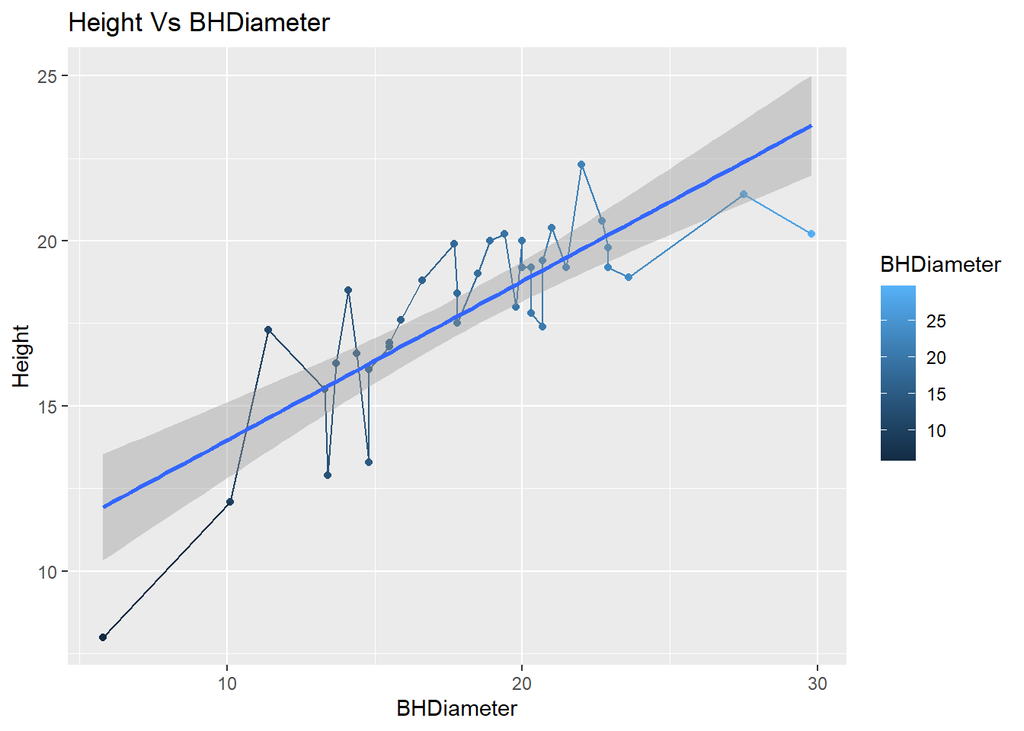

```r
g=ggplot(spruce, aes(x=BHDiameter,y=Height,color=BHDiameter))
g=g+geom_point() + geom_line()+ geom_smooth(method="lm")
g+ggtitle("Height Vs BHDiameter")
```

# Task 7

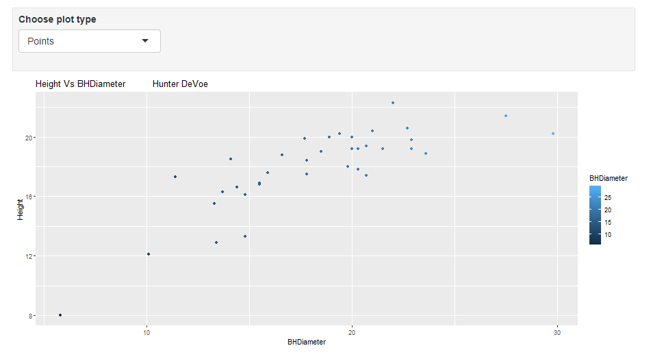

“Points”

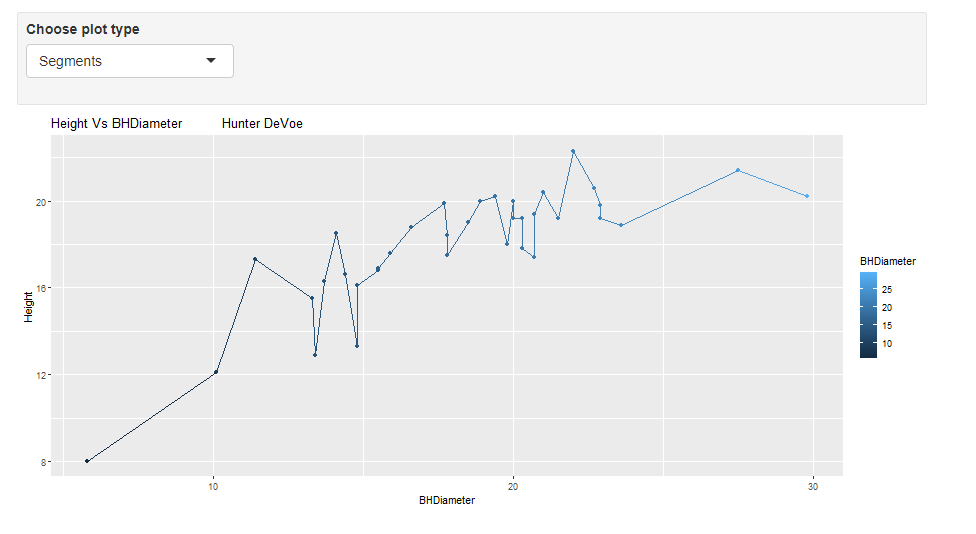

“Segments”

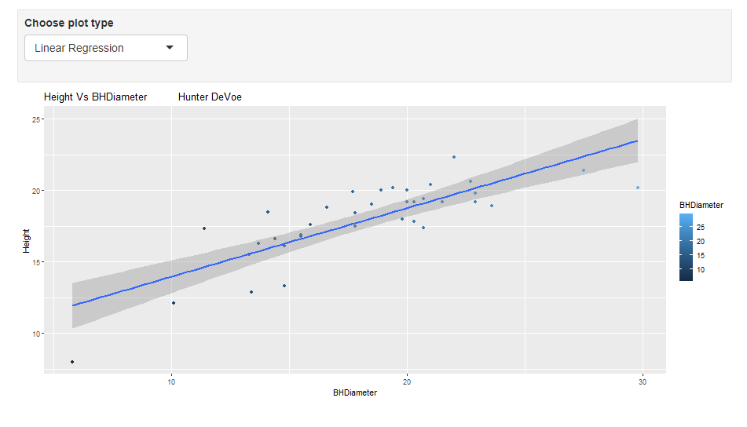

“Linear Regression”

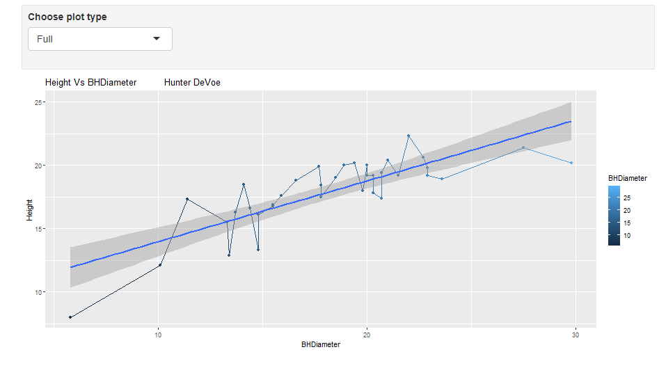

“Full”

```r
# CLEAN UP #################################################

# Clear environment
rm(list = ls())

# Clear packages
p_unload(all)  # Remove all add-ons
```

```
## The following packages have been unloaded:
## s20x, shiny, lattice, forcats, stringr, dplyr, purrr, readr, tidyr, tibble, ggplot2, tidyverse, pacman
```

```r
# Clear plots
dev.off()  # But only if there IS a plot
```

```r
# Clear console
cat("\014")  # ctrl+L
```

```r
# Clear mind :)
```